# ZEAL DTA — R/qtl (bcsft) on the TeoNAM JLM grid: LOD profile + per-family effects

## Candidate gene registry

Curated evidence for each **candidate** (tier, causal direction, evidence type, phenotype, and a DOI link) from the tracked registry (`reference/candidate_genes.csv` × `candidate_evidence.csv`). These are the genes marked on the LOD profile above; loci without B73 v5 coordinates still appear here but are not plotted.

```r
source(here::here("scripts/teonam_notebook_plots.R"))
candidate_table(TRAIT)
```

Candidate genes for DTA from the tracked registry (reference/candidate_*.csv): 11 loci (11 mapped to B73 v5, 0 unmapped). DOI links where curated; “TODO” = evidence not yet curated.

| gene | full name | locus | tier | direction | evidence | phenotype / note | reference |
| --- | --- | --- | --- | --- | --- | --- | --- |
| *zagl1* |  | 1:283.8 Mb |  |  |  |  | TODO |
| *zmads69* |  | 3:161.2 Mb |  |  |  |  | TODO |
| *zcn12* |  | 3:202.8 Mb |  |  |  |  | TODO |
| *tu1* | tu1 (tunicate1 / ZMM19 / MADS19) | 4:183.9 Mb |  |  |  |  | TODO |
| *zmm31* |  | 5:7.4 Mb |  |  |  |  | TODO |
| *si1* |  | 6:94.5 Mb |  |  |  |  | TODO |
| *zag1* |  | 6:142.7 Mb |  |  |  |  | TODO |
| *dlf1* |  | 7:184.5 Mb |  |  |  |  | TODO |
| *zcn8* |  | 8:126.7 Mb |  |  |  |  | TODO |
| *zmcct9* |  | 9:121.0 Mb |  |  |  |  | TODO |
| *zmcct10* |  | 10:96.2 Mb |  |  |  |  | TODO |

## Significant peaks (taxon model, α = 0.05)

R/qtl’s `summary()` reports **at most one peak per chromosome**. That is the table below — position and the **1.5-LOD confidence interval in v5 Mb**, plus any **flowering candidate** whose gene body falls inside.

```r
cipk <- fread(file.path(RQ, "zeal_dta_peaks_ci_taxon.csv"))
knitr::kable(
  cipk[order(chr, -lod), .(
    chr,
    `pos (cM)` = round(pos, 1), `pos (Mb)` = round(bp_of(marker) / 1e6, 1),
    LOD = round(lod, 2), pval, marker,
    `1.5-LOD CI (Mb)` = ci_str(ci_left, ci_right),
    `candidate in CI` = mapply(cand_in_ci, chr, ci_left, ci_right)
  )],
  caption = "Genome-wide significant QTL, taxon model (1000-perm threshold). One peak per chromosome (R/qtl summary), with the 1.5-LOD interval in v5 Mb and any flowering candidate whose gene body falls inside."
)
```

Genome-wide significant QTL, taxon model (1000-perm threshold). One peak per chromosome (R/qtl summary), with the 1.5-LOD interval in v5 Mb and any flowering candidate whose gene body falls inside.

| chr | pos (cM) | pos (Mb) | LOD | pval | marker | 1.5-LOD CI (Mb) | candidate in CI |
| --- | --- | --- | --- | --- | --- | --- | --- |
| 9 | 6.5 | 4.5 | 8.36 | 0 | S9_4522630 | 1.9–31.7 | – |
| 10 | 53.3 | 101.4 | 9.26 | 0 | S10_101418767 | 95.9–123.3 | zmcct10 |

### Multi-peak refinement (airmine `refine_peaks`)

A single chromosome can carry **more than one** DTA QTL. To resolve them, `scripts/detect_peaks.R` (ported from the airmine QTL pipeline) Akima-interpolates each significant chromosome’s LOD curve (10×), runs `pracma::findpeaks` for up to 5 sub-peaks above the permutation threshold, takes each sub-peak’s **1.5-LOD-drop interval**, and resolves overlapping sub-peaks into a maximal set of **non-overlapping** QTL via an interval graph (igraph independent vertex sets). Positions and the 1.5-LOD-drop confidence intervals are shown in **v5 Mb** (markers are v5-named, so `pos (Mb)` reads off the name), with the **candidate-in-CI** flag. Peak splitting from genotyping noise is handled **before** the scan, not here: the hard RTIGER/projected calls carry het/hom-teosinte miscalls that punch artificial LOD dives (which would split a QTL and clip its CI). `calc.genoprob` runs the R/qtl HMM with a realistic `error.prob` so those calls are down-weighted, and the scans use the resulting genotype **probabilities** (Haley–Knott) / **expected dosage** (per-taxon) rather than raw calls — so the LOD curve fed to peak detection is already error-corrected.

```r
refined <- function(tag) {
  r <- fread(file.path(RQ, sprintf("zeal_dta_peaks_refined_%s.csv", tag)))
  if (nrow(r) == 0) {
    return(r)
  }
  r[order(chr, -lod), .(
    chr,
    `pos (cM)` = round(pos, 1), `pos (Mb)` = round(bp_of(marker) / 1e6, 1),
    LOD = round(lod, 2), `perm 5% thr` = round(thresh, 2), marker,
    `1.5-LOD CI (Mb)` = ci_str(ci_left, ci_right),
    `candidate in CI` = mapply(cand_in_ci, chr, ci_left, ci_right)
  )]
}
rt <- refined("taxon")
if (nrow(rt) == 0) {
  cat("No refined peaks (no chromosome exceeded the permutation threshold).")
} else {
  knitr::kable(rt, caption = sprintf(
    "Refined multi-peak QTL, taxon model (%d QTL across %d chromosomes) vs %d one-per-chr peaks above. Multiple rows on one chromosome = linked QTL split by the interval-graph deconvolution.",
    nrow(rt), uniqueN(rt$chr), nrow(peakrow("taxon"))
  ))
}
```

Refined multi-peak QTL, taxon model (4 QTL across 2 chromosomes) vs 2 one-per-chr peaks above. Multiple rows on one chromosome = linked QTL split by the interval-graph deconvolution.

| chr | pos (cM) | pos (Mb) | LOD | perm 5% thr | marker | 1.5-LOD CI (Mb) | candidate in CI |
| --- | --- | --- | --- | --- | --- | --- | --- |
| 9 | 6.5 | 4.5 | 8.36 | 5.12 | S9_4522630 | 1.9–31.7 | – |
| 10 | 53.3 | 101.4 | 9.26 | 5.12 | S10_101418767 | 95.9–104.5 | zmcct10 |
| 10 | 56.8 | 117.7 | 8.32 | 5.12 | S10_117670536 | 116.4–123.3 | – |
| 10 | 46.7 | 76.8 | 5.58 | 5.12 | S10_76811299 | 33.9–78.2 | – |

## Per-taxon (family-resolved), additive-only with QC

- **Phenotype cleaning is upstream:** the DTA BLUEs come from raw plots already cleaned by a per-field×taxa **upper Tukey fence** (Q3 + 3·IQR, late tail only) applied before SpATS in `zeal_spats_blues.R` — so the very-late plots are removed at source, not re-fenced here.
- **Additive-only model on HMM expected dosage** — LOD from `lm(DTA ~ E[teosinte dosage])`, 1 df, where `E[g] = P(het) + 2·P(hom-teo)` comes from the error-aware `calc.genoprob` (so het/hom miscalls are down-weighted *before* the scan, not smoothed afterwards); no dominance term, so a near-empty homozygous-teosinte class cannot make the fit rank-deficient. QC class-counts below use the hard calls.
- **Marker filters:** (a) **fraction introgressed (HET or ALT) > 0.05** (HET *or* ALT because the caller calls het over hom-ALT — BC₂S₃ expectation is ~10.9% hom-teosinte vs ~3.1% het); (b) **≥ 3 samples in every present genotype class** (empty classes are fine under an additive model — they carry no parameter).

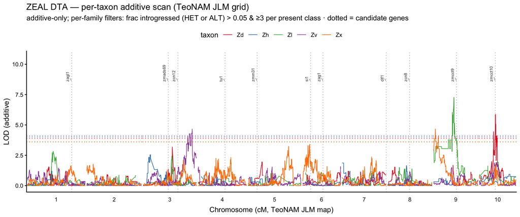

```r
bt <- fread(file.path(RQ, "zeal_dta_scanone_by_taxon.csv"))[is.finite(lod)]
pal5 <- c(Zd = "#E41A1C", Zh = "#377EB8", Zl = "#4DAF4A", Zv = "#984EA3", Zx = "#FF7F00")
ytop_bt <- max(bt$lod, na.rm = TRUE)
pt <- ggplot(bt, aes(pos, lod, colour = taxon)) +
  geom_vline(data = cl, aes(xintercept = cm), inherit.aes = FALSE, linetype = "dotted", colour = "grey55", linewidth = 0.3) +
  ggrepel::geom_text_repel(
    data = cl, aes(x = cm, y = ytop_bt * 1.18, label = symbol), inherit.aes = FALSE,
    size = 2.2, colour = "grey25", angle = 90, hjust = 0, direction = "x", segment.size = 0.2, min.segment.length = 0
  ) +
  expand_limits(y = ytop_bt * 1.45) +
  geom_line(linewidth = 0.4) +
  geom_hline(
    data = unique(bt[, .(taxon, thr5)]), aes(yintercept = thr5, colour = taxon),
    linetype = "dotted", linewidth = 0.4, show.legend = FALSE
  ) +
  facet_grid(~chr, scales = "free_x", space = "free_x", switch = "x") +
  scale_colour_manual(values = pal5, name = "taxon") +
  labs(
    x = "Chromosome (cM, TeoNAM JLM map)", y = "LOD (additive)",
    title = "ZEAL DTA — per-taxon additive scan (TeoNAM JLM grid)",
    subtitle = "additive-only; per-family filters: frac introgressed (HET or ALT) > 0.05 & ≥3 per present class · dotted = candidate genes"
  ) +
  theme_classic(base_size = 11) +
  theme(
    axis.text.x = element_blank(), axis.ticks.x = element_blank(),
    panel.spacing = unit(0.05, "lines"), strip.placement = "outside",
    strip.background = element_blank(), legend.position = "top"
  ) +
  scale_x_continuous(expand = c(0.01, 0))
ggsave(file.path(RQ, "zeal_dta_lod_by_taxon.png"), pt, width = 11, height = 4.6, dpi = 200, bg = "white")
pt
```

```r
btpk <- bt[,
  {
    i <- which.max(lod)
    ch <- chr[i]
    L <- lod[i]
    ins <- .SD[chr == ch][lod >= L - 1.5]
    lbp <- min(bp_of(ins$marker))
    hbp <- max(bp_of(ins$marker))
    .(
      chr = ch, `pos (cM)` = round(pos[i], 1), `pos (Mb)` = round(bp_of(marker[i]) / 1e6, 1),
      marker = marker[i], `max LOD` = round(L, 2), `perm 5% thr` = round(thr5[1], 2),
      sig = fifelse(L > thr5[1], "yes", "no"),
      `1.5-LOD CI (Mb)` = sprintf("%.1f–%.1f", lbp / 1e6, hbp / 1e6),
      `candidate in CI` = cand_in_ci(ch, lbp, hbp)
    )
  },
  by = taxon
][order(-`max LOD`)]
knitr::kable(btpk, caption = "Genome-wide additive peak per taxon (filtered: frac introgressed > 0.05 & ≥3 per present class), with the per-taxon 1000-permutation 5% threshold. 1.5-LOD interval in v5 Mb and any flowering candidate inside. 'sig' = the family's peak exceeds its own threshold. One peak per taxon.")
```

Genome-wide additive peak per taxon (filtered: frac introgressed > 0.05 & ≥3 per present class), with the per-taxon 1000-permutation 5% threshold. 1.5-LOD interval in v5 Mb and any flowering candidate inside. ‘sig’ = the family’s peak exceeds its own threshold. One peak per taxon.

| taxon | chr | pos (cM) | pos (Mb) | marker | max LOD | perm 5% thr | sig | 1.5-LOD CI (Mb) | candidate in CI |
| --- | --- | --- | --- | --- | --- | --- | --- | --- | --- |
| Zl | 9 | 67.2 | 94.3 | S9_94322165 | 7.28 | 3.60 | yes | 37.2–98.5 | – |
| Zd | 10 | 53.1 | 100.9 | S10_100917157 | 5.87 | 3.89 | yes | 76.8–104.6 | zmcct10 |
| Zv | 3 | 160.8 | 230.3 | S3_230298803 | 4.66 | 4.02 | yes | 222.8–230.6 | – |
| Zx | 9 | 6.5 | 4.5 | S9_4522630 | 4.66 | 3.61 | yes | 2.7–8.0 | – |
| Zh | 3 | 23.5 | 6.6 | S3_6570943 | 2.54 | 4.11 | no | 4.7–140.1 | – |

### Per-taxon multi-peak refinement

The same `find_subpeaks` deconvolution applied to each family’s LOD profile — so a taxon carrying two QTL on one chromosome (or across the genome) shows all of them, not just its single global maximum. Thresholded at each family’s own per-taxon permutation 5% (`thr5`).

```r
btr <- fread(file.path(RQ, "zeal_dta_peaks_refined_by_taxon.csv"))
if (nrow(btr) == 0) {
  cat("No per-taxon refined peaks cleared the per-family thresholds.")
} else {
  knitr::kable(
    btr[order(taxon, chr, -lod), .(
      taxon, chr,
      `pos (cM)` = round(pos, 1), `pos (Mb)` = round(bp_of(marker) / 1e6, 1),
      LOD = round(lod, 2), `perm 5% thr` = round(thr5, 2), marker,
      `1.5-LOD CI (Mb)` = ci_str(ci_left, ci_right),
      `candidate in CI` = mapply(cand_in_ci, chr, ci_left, ci_right)
    )],
    caption = sprintf(
      "Refined per-taxon multi-peak QTL (%d QTL across %d families), 1.5-LOD-drop CIs in v5 Mb.",
      nrow(btr), uniqueN(btr$taxon)
    )
  )
}
```

Refined per-taxon multi-peak QTL (4 QTL across 4 families), 1.5-LOD-drop CIs in v5 Mb.

| taxon | chr | pos (cM) | pos (Mb) | LOD | perm 5% thr | marker | 1.5-LOD CI (Mb) | candidate in CI |
| --- | --- | --- | --- | --- | --- | --- | --- | --- |
| Zd | 10 | 53.1 | 100.9 | 5.87 | 3.89 | S10_100917157 | 74.2–105.1 | zmcct10 |
| Zl | 9 | 67.2 | 94.3 | 7.28 | 3.60 | S9_94322165 | 35.2–99.8 | – |
| Zv | 3 | 160.8 | 230.3 | 4.66 | 4.02 | S3_230298803 | 222.6–230.7 | – |
| Zx | 9 | 6.5 | 4.5 | 4.66 | 3.61 | S9_4522630 | 2.5–8.1 | – |

## Allele effect at the Zd chr10 peak (near ZmCCT10), by taxon

```r
# derive the effect-plot marker from the current Zd per-family peak (no hardcoding,
# so this cannot drift from the peaks table above)
mk <- bt[taxon == "Zd"][which.max(lod), marker]
zd_lod <- bt[taxon == "Zd"][which.max(lod), round(lod, 2)]
zd_mb <- round(bp_of(mk) / 1e6, 1)
zd_dist <- round(abs(bp_of(mk) - CCT_BP) / 1e6, 1)
# 1.5-LOD interval (v5 Mb) for the Zd chr10 peak + ZmCCT10 containment
.ins <- bt[taxon == "Zd" & chr == 10][lod >= max(lod) - 1.5]
zd_ci_lo <- round(min(bp_of(.ins$marker)) / 1e6, 1)
zd_ci_hi <- round(max(bp_of(.ins$marker)) / 1e6, 1)
zd_cct_in <- CCT_BP >= min(bp_of(.ins$marker)) & CCT_BP <= max(bp_of(.ins$marker))
.g <- pull.geno(cross)[, mk]
.d <- as.numeric(pull.pheno(cross, "DTA"))
.ss <- unique(fread(here("data/zeal/samplesheet_3way.csv"))[, .(pedigree, taxon)], by = "pedigree")
.tx <- .ss[match(as.character(pull.pheno(cross, "id")), pedigree), taxon]
.k <- .tx == "Zd" & is.finite(.d) & !is.na(.g)
zd_ador <- round(coef(lm(.d[.k] ~ c(0, 1, 2)[.g[.k]]))[2], 2)
zd_nbb <- sum(.g[.k] == 3)
zd_bbaa <- round(mean(.d[.k][.g[.k] == 3]) - mean(.d[.k][.g[.k] == 1]), 1)
```

```r
cat(sprintf(
  paste0(
    "The Zd per-family DTA peak, `%s` (chr10 ≈ %s Mb), lies **~%s Mb from ZmCCT10** ",
    "(96.2 Mb, Chen's DTA10.1), and its **1.5-LOD interval (%s–%s Mb) %s ZmCCT10** — so the ",
    "gene %s. In Zd it is a **large-effect, teosinte-late QTL**: **%+.2f days per teosinte allele, ",
    "%+.1f days B/B−A/A** (n_BB = %d), LOD %s.\n"
  ),
  mk, zd_mb, zd_dist, zd_ci_lo, zd_ci_hi,
  if (zd_cct_in) "includes" else "does not include",
  if (zd_cct_in) "sits inside the support interval" else "falls just outside the support interval",
  zd_ador, zd_bbaa, zd_nbb, zd_lod
))
```

The Zd per-family DTA peak, `S10_100917157` (chr10 ≈ 100.9 Mb), lies **~4.7 Mb from ZmCCT10** (96.2 Mb, Chen’s DTA10.1), and its **1.5-LOD interval (76.8–104.6 Mb) includes ZmCCT10** — so the gene sits inside the support interval. In Zd it is a **large-effect, teosinte-late QTL**: **+1.73 days per teosinte allele, +4.2 days B/B−A/A** (n_BB = 12), LOD 5.87.

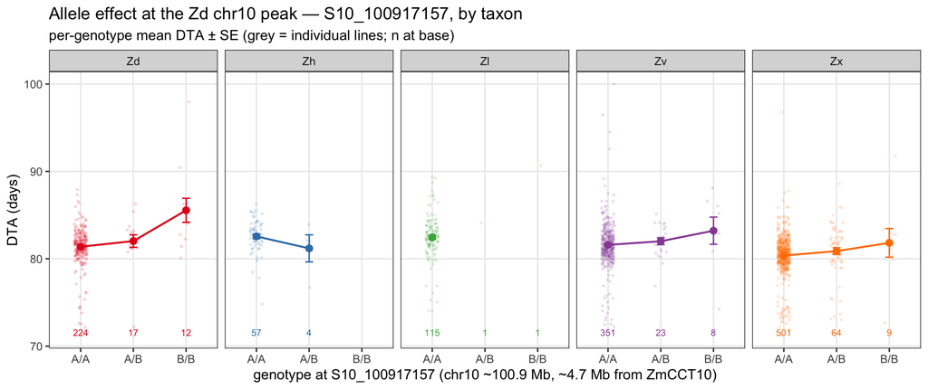

```r
gm <- pull.geno(cross)[, mk] # mk from the zd-setup chunk (current Zd peak)
dta <- as.numeric(pull.pheno(cross, "DTA")) # DTA > 100 already dropped upstream
ids <- as.character(pull.pheno(cross, "id"))
ss <- fread(here("data/zeal/samplesheet_3way.csv"))[, .(pedigree, taxon)]
d <- data.table(
  taxon = ss[match(ids, pedigree), taxon],
  geno = factor(c("A/A", "A/B", "B/B")[gm], levels = c("A/A", "A/B", "B/B")), dta
)[!is.na(dta) & !is.na(geno) & taxon %in% c("Zd", "Zh", "Zl", "Zv", "Zx")]
summ <- d[, .(mean = mean(dta), se = sd(dta) / sqrt(.N), n = .N), by = .(taxon, geno)]
shown <- summ[n >= 3] # estimate drawn only for classes with >= 3 samples
ef <- ggplot(d, aes(geno, dta, colour = taxon)) +
  geom_jitter(width = 0.12, alpha = 0.12, size = 0.5) +
  geom_line(data = shown, aes(y = mean, group = taxon), linewidth = 0.7) +
  geom_point(data = shown, aes(y = mean), size = 2.2) +
  geom_errorbar(data = shown, aes(y = mean, ymin = mean - se, ymax = mean + se), width = 0.15) +
  geom_text(data = summ, aes(label = n), y = min(d$dta), vjust = 0, size = 2.5, show.legend = FALSE) +
  facet_wrap(~taxon, nrow = 1) +
  scale_colour_manual(values = pal5, guide = "none") +
  labs(
    x = sprintf("genotype at %s (chr10 ~%s Mb, ~%s Mb from ZmCCT10)", mk, zd_mb, zd_dist), y = "DTA (days)",
    title = sprintf("Allele effect at the Zd chr10 peak — %s, by taxon", mk),
    subtitle = "per-genotype mean DTA ± SE (grey = individual lines; n at base)"
  ) +
  theme_bw(base_size = 11) +
  theme(panel.grid.minor = element_blank())
ggsave(file.path(RQ, sprintf("zeal_dta_%s_effect.png", mk)), ef, width = 10, height = 4.2, dpi = 200, bg = "white")
ef
```

```r
eff <- dcast(summ, taxon ~ geno, value.var = "mean")
ns <- dcast(summ, taxon ~ geno, value.var = "n")
setnames(ns, names(ns)[-1], paste0("n ", names(ns)[-1]), skip_absent = TRUE)
knitr::kable(merge(eff, ns, by = "taxon"),
  digits = 1,
  caption = paste0("Mean DTA by genotype and taxon at ", mk, ", with cell counts.")
)
```

Mean DTA by genotype and taxon at S10_100917157, with cell counts.

| taxon | A/A | A/B | B/B | n A/A | n A/B | n B/B |
| --- | --- | --- | --- | --- | --- | --- |
| Zd | 81.4 | 82.0 | 85.5 | 224 | 17 | 12 |
| Zh | 82.6 | 81.2 | NA | 57 | 4 | NA |
| Zl | 82.5 | 84.1 | 90.7 | 115 | 1 | 1 |
| Zv | 81.6 | 82.0 | 83.2 | 351 | 23 | 8 |
| Zx | 80.4 | 80.9 | 81.8 | 501 | 64 | 9 |

**Read.** *Effect size and statistical support are separate — read effects in days, LOD/n as the support.* In maize a DTA shift of a few days is a **large** effect, the scale of the major cloned flowering genes.

So after honest phenotype cleaning the ZEAL DTA scan recovers a **large-effect, well-supported, teosinte-late QTL in the ZmCCT10 region** — pooled *and* in Zd — consistent with TeoNAM’s DTA10.1, plus a chr9 teosinte-early locus. These are not “modest” effects; they are large, and the chr10 one is well supported.